# Time Series HW6

B082040005 高念慈

2023-04-10

## 2.

1. Simulate 100 observations from the following AR(1) process:
   $$Z_t = 0.5 - 0.5Z_{t-1} +
   \epsilon_{t}$$
   Where $Z_0 = 0$ and $\epsilon_{t} ~i.i.d.~ N(0,0.3)$
   Compute the sample ACF $\hat\rho_k$ for k=0,1,2,…,10 and PACF $\hat{\phi_{kk}}$ for k=0,1,2,…,10.
- $Z_t = 0.5 - 0.5Z_{t-1} + \epsilon_{t}$
- $\mu=\frac{\phi_0}{1-\phi_1}=\frac{0.5}{1+0.5}=\frac{1}{3}$
- $Z_t - \frac{1}{3} = - 0.5(Z_{t-1}-\frac{1}{3}) + \epsilon_{t}$
- $\dot{Z_t} = - 0.5\dot{Z_{t-1}} + \epsilon_{t}$
- R中常數項為$\mu$
- $Z_t = \dot{Z_t}+\mu$

### 模擬

- [R 中 Arima.sim() 模型的輸入值是多少？](https://stackoverflow.com/questions/51296915/whats-the-input-value-for-model-in-arima-sim-in-r)
- [使用指定的非零均值和 AR 係數在 R 中模擬 AR(1) 過程](https://stats.stackexchange.com/questions/305224/simulate-ar1-process-in-r-with-specified-nonzero-mean-and-ar-coefficient)

```r
set.seed(20230331)
yt = arima.sim(list(order=c(1,0,0), ar=-0.5, sq=sqrt(0.3)), n=100)  # c(1,0,0):AR模型
ar1_100 = yt + 1/3
head(ar1_100)
```

```
## [1]  0.8794098 -1.9086424  0.7830030  2.4863706 -0.4684484 -0.7201929
```

### Compute the sample ACF and PACF

- $\rho_k = (\phi_1)^k$
- $\hat{\phi_{kk}} : \phi_{11}=\rho_1=\phi_{1}=-0.5, other = 0$

```r
rho_k = c()

for (i in 0:10)
 rho_k = c(rho_k,(-0.5)^i)

rho_k                         # ACF
```

```
##  [1]  1.0000000000 -0.5000000000  0.2500000000 -0.1250000000  0.0625000000
##  [6] -0.0312500000  0.0156250000 -0.0078125000  0.0039062500 -0.0019531250
## [11]  0.0009765625
```

### Compute the sample ACF and PACF

```r
acf(ar1_100, type = "correlation", plot = FALSE,lag.max = 10)  # ACF
```

```
##
## Autocorrelations of series 'ar1_100', by lag
##
##      0      1      2      3      4      5      6      7      8      9     10
##  1.000 -0.402  0.137 -0.038 -0.062  0.059 -0.017 -0.042  0.207 -0.131  0.062
```

```r
acf(ar1_100, type = "partial", plot = FALSE, lag.max = 10)     # PACF
```

```
##
## Partial autocorrelations of series 'ar1_100', by lag
##
##      1      2      3      4      5      6      7      8      9     10
## -0.402 -0.030  0.008 -0.085  0.002  0.020 -0.055  0.198  0.040 -0.002
```

2. Repeating the procedure(程序) of (i) for 1000 times, find the values of  
   the mean, variance and covariance of$\hat\rho_1,\hat\rho_2$ and $\hat\rho_3$

### mean, variance and covariance

```r
set.seed(20220328)

M = 1000

rho_1 = rep(0,M);rho_2 = rep(0,M);rho_3 = rep(0,M)

for (i in 1:M){
  yt_1000 = arima.sim(list(order=c(1,0,0), ar=-0.5, sq=sqrt(0.3)), n=100)  # c(1,0,0):AR模型
  ar1_1000 = yt_1000 + 1/3

  ar100_acf = acf(ar1_1000, type = "correlation", plot = FALSE,lag.max = 3)[[1]]  # ACF
  rho_1[i] = ar100_acf[2]
  rho_2[i] = ar100_acf[3]
  rho_3[i] = ar100_acf[4]
}

cbind(mean_rho = c(mean(rho_1),mean(rho_2),mean(rho_3)),
      var_rho = c(var(rho_1),var(rho_2),var(rho_3)))
```

```
##        mean_rho     var_rho
## [1,] -0.4937733 0.007009579
## [2,]  0.2347892 0.012109305
## [3,] -0.1179250 0.013892444
```

### covariance

```r
rbind(co_rho12 = cov(rho_1,rho_2),
      co_rho23 = cov(rho_2,rho_3),
      co_rho13 = cov(rho_1,rho_3))
```

```
##                  [,1]
## co_rho12 -0.006991068
## co_rho23 -0.010039551
## co_rho13  0.005001310
```

3. Compare the result of (ii) with the Bartlett’s approximation.

from HW5

## 全錯

- $Var(\hat\rho_k) \approx \frac{2}{n}(\phi_1^{2k}-1)(\frac{\phi_1^2}{1-\phi_1^2})$

```r
phi1 = -0.5
n = 1000

var_approx = function(k){
  return((2/n)*(phi1^(2*k)-1)*(phi1^2/(1-phi1^2)))
}

rbind(var_rho_1=var_approx(1),
      var_rho_2=var_approx(2),
      var_rho_3=var_approx(3))
```

```
##                  [,1]
## var_rho_1 -0.00050000
## var_rho_2 -0.00062500
## var_rho_3 -0.00065625
```

## 訂正

```r
var_sample_ACF <- function(k,m,n){
  var_rho_k <- ((1-m^(2*n))*(1+m^2)/(1-m^2)-2*n*m^(2*n))*(1/k)
  return(var_rho_k)
}

rbind(var_rho_1=var_sample_ACF(100,-0.5,1),
      var_rho_2=var_sample_ACF(100,-0.5,2),
      var_rho_3=var_sample_ACF(100,-0.5,3))
```

```
##                 [,1]
## var_rho_1 0.00750000
## var_rho_2 0.01312500
## var_rho_3 0.01546875
```

- 隨著 n 越大應該是要越接近的
- mean_rho1: -0.4937733 var_rho1: 0.007009579
- mean_rho2: 0.2347892 var_rho2: 0.012109305
- mean_rho3: -0.1179250 var_rho3: 0.013892444
- co_rho12: -0.006991068
- co_rho23: -0.010039551
- co_rho13: 0.005001310

## 3.

Simulate a series of 100 observations from each of the following models  
where the $a_t$ is a Gaussian white noise process with $E(a_t)=0$ and $Var(a_t) = 1$:

$$(a) Z_t − 0.5Z_{t-1} = a_t$$
$$(b) Z_t + 0.98Z_{t-1} = a_t$$
$$(c) Z_t − 1.3Z_{t-1} + 0.4Z_{t-2} = a_t$$
$$(d) Z_t − 1.2Z_{t-1} +0.8Z_{t-2} =
a_t$$
For each case, plot the simulated series, and calculate and study its sample ACF
$\hat\rho_k$ for k=0,1,2,…,20 and PACF $\hat{\phi_{kk}}$ for k=0,1,2,…,20.

### 模擬(a)

```r
set.seed(20230331)
yta = arima.sim(list(order=c(1,0,0), ar=0.5, sq=1), n=100)  # c(1,0,0):AR模型
ar1_a = yta + 0
head(ar1_a)
```

```
## [1] -0.1147034 -2.0262893 -1.6844628  1.5356407  1.0425573 -0.9331384
```

### plot

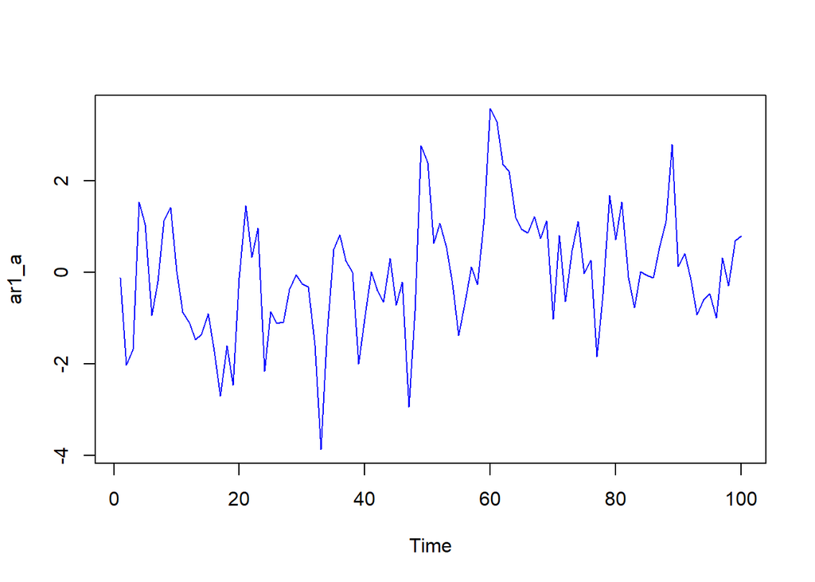

```r
ts.plot(ar1_a,col="blue")
```

### Compute the sample ACF and PACF

```r
acf(ar1_a, type = "correlation", plot = FALSE,lag.max = 20)  # ACF
```

```
##
## Autocorrelations of series 'ar1_a', by lag
##
##      0      1      2      3      4      5      6      7      8      9     10
##  1.000  0.534  0.210  0.073  0.005  0.058  0.069  0.139  0.215  0.112  0.106
##     11     12     13     14     15     16     17     18     19     20
##  0.106  0.087  0.167  0.234  0.184  0.072 -0.013  0.003  0.003  0.019
```

```r
acf(ar1_a, type = "partial", plot = FALSE, lag.max = 20)     # PACF
```

```
##
## Partial autocorrelations of series 'ar1_a', by lag
##
##      1      2      3      4      5      6      7      8      9     10     11
##  0.534 -0.104  0.007 -0.027  0.103 -0.005  0.130  0.114 -0.094  0.105  0.033
##     12     13     14     15     16     17     18     19     20
##  0.017  0.133  0.130 -0.050 -0.070 -0.002  0.009 -0.043  0.017
```

- $\rho_k = (\phi_1)^k$
- $\hat{\phi_{kk}} : \phi_{11}=\rho_1=\phi_{1}=0.5, other = 0$

```r
rho_k_a = c()

for (i in 0:20)
 rho_k_a = c(rho_k_a,(0.5)^i)

rho_k_a                         # ACF
```

```
##  [1] 1.000000e+00 5.000000e-01 2.500000e-01 1.250000e-01 6.250000e-02
##  [6] 3.125000e-02 1.562500e-02 7.812500e-03 3.906250e-03 1.953125e-03
## [11] 9.765625e-04 4.882812e-04 2.441406e-04 1.220703e-04 6.103516e-05
## [16] 3.051758e-05 1.525879e-05 7.629395e-06 3.814697e-06 1.907349e-06
## [21] 9.536743e-07
```

### 模擬(b)

```r
set.seed(20230331)
ytb = arima.sim(list(order=c(1,0,0), ar=-0.98, sq=1), n=100)  # c(1,0,0):AR模型
ar1_b = ytb + 0
head(ar1_b)
```

```
## [1] -5.043674  3.661535 -4.293398  5.334082 -3.833109  3.386770
```

### plot

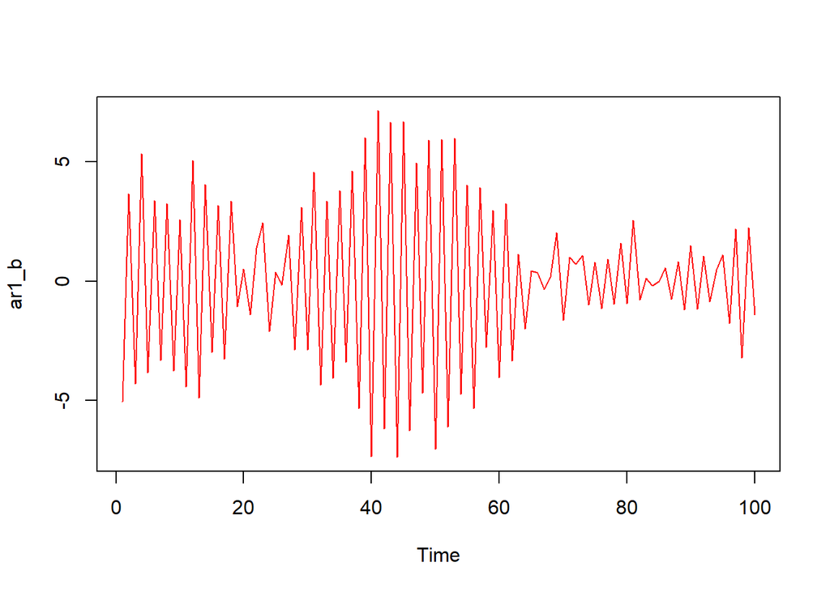

```r
ts.plot(ar1_b,col="red")
```

### Compute the sample ACF and PACF

```r
acf(ar1_b, type = "correlation", plot = FALSE,lag.max = 20)  # ACF
```

```
##
## Autocorrelations of series 'ar1_b', by lag
##
##      0      1      2      3      4      5      6      7      8      9     10
##  1.000 -0.949  0.908 -0.881  0.852 -0.812  0.773 -0.743  0.718 -0.682  0.643
##     11     12     13     14     15     16     17     18     19     20
## -0.597  0.552 -0.502  0.453 -0.407  0.365 -0.329  0.276 -0.230  0.190
```

```r
acf(ar1_b, type = "partial", plot = FALSE, lag.max = 20)     # PACF
```

```
##
## Partial autocorrelations of series 'ar1_b', by lag
##
##      1      2      3      4      5      6      7      8      9     10     11
## -0.949  0.069 -0.137 -0.014  0.105 -0.037 -0.046  0.049  0.092 -0.053  0.143
##     12     13     14     15     16     17     18     19     20
## -0.056  0.085 -0.023  0.012  0.004 -0.053 -0.193 -0.022 -0.026
```

- $\rho_k = (\phi_1)^k$
- $\hat{\phi_{kk}} : \phi_{11}=\rho_1=\phi_{1}=-0.98, other = 0$

```r
rho_k_b = c()

for (i in 0:20)
 rho_k_b = c(rho_k_b,(-0.98)^i)

rho_k_b                         # ACF
```

```
##  [1]  1.0000000 -0.9800000  0.9604000 -0.9411920  0.9223682 -0.9039208
##  [7]  0.8858424 -0.8681255  0.8507630 -0.8337478  0.8170728 -0.8007314
## [13]  0.7847167 -0.7690224  0.7536419 -0.7385691  0.7237977 -0.7093218
## [19]  0.6951353 -0.6812326  0.6676080
```

### 模擬(c)

```r
set.seed(20230331)
ytc = arima.sim(list(order=c(2,0,0), ar=c(1.3,-0.4), sq=1), n=100)  # c(1,0,0):AR模型
ar1_c = ytc + 0
head(ar1_c)
```

```
## [1] -6.345467 -3.619559 -2.569870 -1.089690 -3.033029 -3.286991
```

### plot

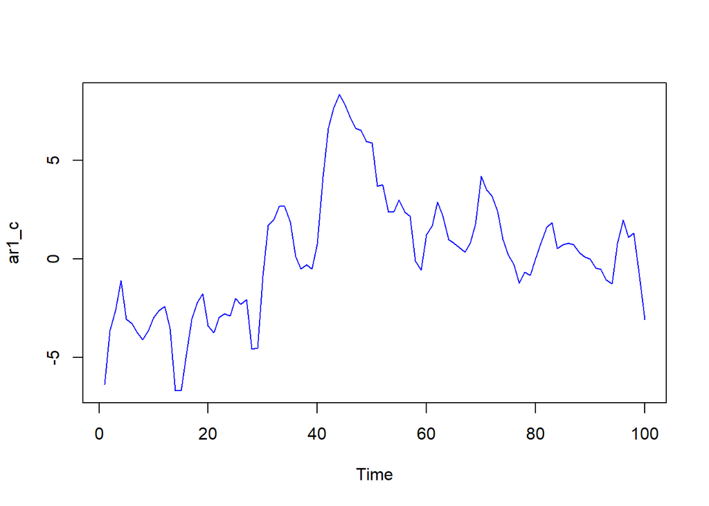

```r
ts.plot(ar1_c,col="blue")
```

### Compute the sample ACF and PACF

```r
acf(ar1_c, type = "correlation", plot = FALSE,lag.max = 20)  # ACF
```

```
##
## Autocorrelations of series 'ar1_c', by lag
##
##     0     1     2     3     4     5     6     7     8     9    10    11    12
## 1.000 0.904 0.782 0.675 0.604 0.564 0.545 0.528 0.504 0.465 0.427 0.393 0.369
##    13    14    15    16    17    18    19    20
## 0.345 0.288 0.214 0.134 0.074 0.047 0.033 0.012
```

```r
acf(ar1_c, type = "partial", plot = FALSE, lag.max = 20)     # PACF
```

```
##
## Partial autocorrelations of series 'ar1_c', by lag
##
##      1      2      3      4      5      6      7      8      9     10     11
##  0.904 -0.187  0.026  0.119  0.087  0.079  0.008  0.003 -0.046  0.030  0.000
##     12     13     14     15     16     17     18     19     20
##  0.020 -0.031 -0.201 -0.083 -0.083  0.012  0.049 -0.041 -0.076
```

- $AR(2):Z_t=\phi_0+\phi_1Z_{t-1}+\phi_2Z_{t-2}+a_t$
- $\rho_k = \phi_1\rho_{k-1}+\phi_2\rho_{k-2},k\geq2$
- $\rho_0=1,\rho_1=\frac{\phi_1}{1-\phi_2}$
- $\hat{\phi_{kk}} : \phi_{11}=\phi_{1}=1.3,\phi_{22}=\phi_{2}=-0.4, other = 0$
- $\hat\rho_k=\frac{10}{7}(\frac{4}{5})^k - \frac{3}{7}(\frac{1}{2})^k,k=0,1,...$

```r
rho_k_c = c()

for (i in 0:20)
 rho_k_c =  c(rho_k_c,(10/7)*(0.8)^i+(-3/7)*(0.5)^i)

rho_k_c                         # ACF
```

```
##  [1] 1.00000000 0.92857143 0.80714286 0.67785714 0.55835714 0.45472143
##  [7] 0.36779500 0.29624493 0.23800041 0.19090256 0.15297316 0.12250409
## [13] 0.09806605 0.07848423 0.06280308 0.05025031 0.04020417 0.03216530
## [19] 0.02573322 0.02058707 0.01646990
```

### 模擬(d)

```r
set.seed(20230331)
ytd = arima.sim(list(order=c(2,0,0), ar=c(1.2,-0.8), sq=1), n=100)  # c(1,0,0):AR模型
ar1_d = ytd + 0
head(ar1_d)
```

```
## [1] -5.142741 -5.060436  1.225517  6.537260  6.299656  3.091521
```

### plot

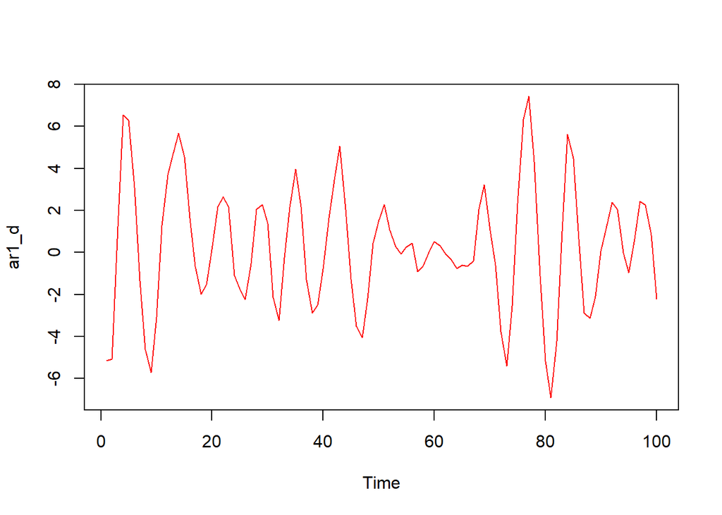

```r
ts.plot(ar1_d,col="red")
```

### Compute the sample ACF and PACF

```r
acf(ar1_d, type = "correlation", plot = FALSE,lag.max = 20)  # ACF
```

```
##
## Autocorrelations of series 'ar1_d', by lag
##
##      0      1      2      3      4      5      6      7      8      9     10
##  1.000  0.667 -0.024 -0.609 -0.769 -0.476  0.033  0.442  0.535  0.304 -0.047
##     11     12     13     14     15     16     17     18     19     20
## -0.290 -0.313 -0.155  0.037  0.150  0.131  0.040 -0.044 -0.073 -0.044
```

```r
acf(ar1_d, type = "partial", plot = FALSE, lag.max = 20)     # PACF
```

```
##
## Partial autocorrelations of series 'ar1_d', by lag
##
##      1      2      3      4      5      6      7      8      9     10     11
##  0.667 -0.844 -0.105 -0.129 -0.091 -0.079 -0.039 -0.072 -0.069  0.108  0.009
##     12     13     14     15     16     17     18     19     20
##  0.025  0.012 -0.072  0.027 -0.102  0.043 -0.087 -0.036 -0.024
```

- $AR(2):Z_t=\phi_0+\phi_1Z_{t-1}+\phi_2Z_{t-2}+a_t$
- $\rho_k = \phi_1\rho_{k-1}+\phi_2\rho_{k-2},k\geq2$
- $\rho_0=1,\rho_1=\frac{\phi_1}{1-\phi_2}$
- $\hat{\phi_{kk}} : \phi_{11}=\phi_{1}=1.2,\phi_{22}=\phi_{2}=-0.8, other = 0$

```r
rho_k_d <- c()

d = (2/3-3/5)/sqrt(4/5)*sin(acos(3*sqrt(5)/10))

for (i in 0:20){
   rho_k_d <- c(rho_k_d,(2*sqrt(5)/5)^i*(cos(i*acos(3*sqrt(5)/10)))+d*(2*sqrt(5)/5)
^i*sin(i*acos(3*sqrt(5)/10)))
}

rho_k_d
```

```
##  [1]  1.000000000  0.636666667 -0.036000000 -0.552533333 -0.634240000
##  [6] -0.319061333  0.124518400  0.404671147  0.385990656  0.139451870
## [11] -0.141450281 -0.281301833 -0.224401975 -0.044240903  0.126432496
## [16]  0.187111718  0.123388065 -0.001623697 -0.100658888 -0.119491708
## [21] -0.062862939
```